# MTH6139 Time Series

### 2.2 Box-Cox transformation

Since we saw that the variance increases with the time I will find the lambda value that stabilizes it from the Box Cox transformation.

```r
(lambda <- BoxCox.lambda(AirPassengers))
```

```
## [1] -0.2947156
```

The lambda value is -0.2947156. I transform the data with this value and plot the result.

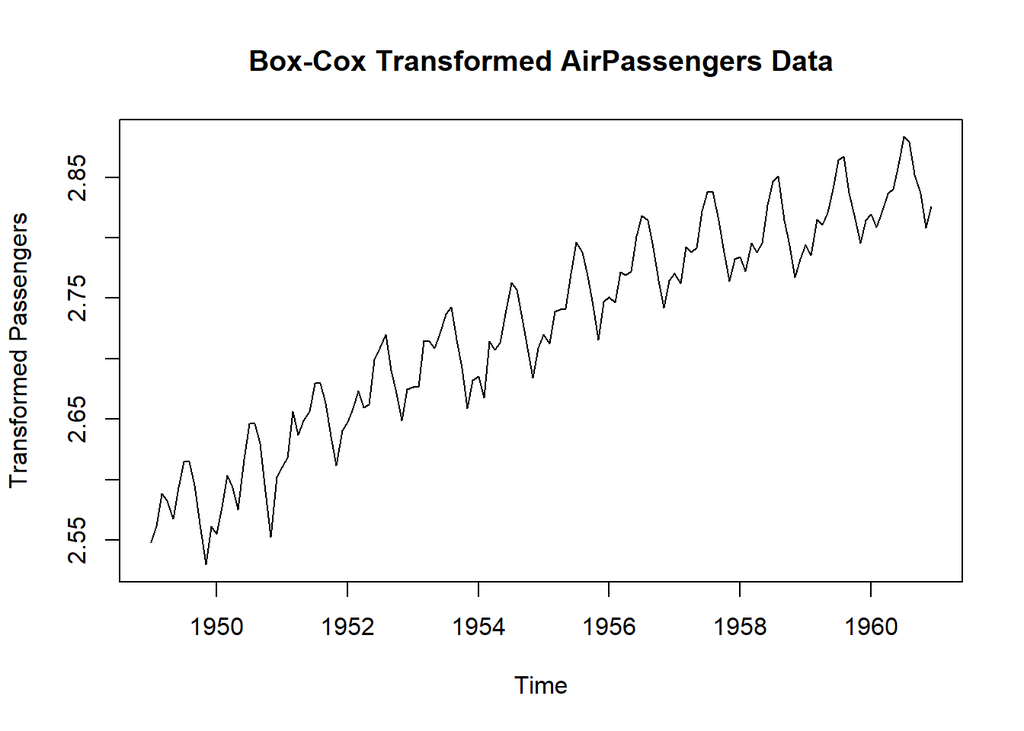

```r
airpassengers_transformed <- BoxCox(AirPassengers, lambda)

plot(airpassengers_transformed, main="Box-Cox Transformed AirPassengers Data", ylab="Transformed Passengers")
```

We can see now that we have solved the problem of non constant variance.

### 2.3 Differences to remove trend

It is required to perform 1 difference in order to remove the trend.

```r
ndiffs(airpassengers_transformed)
```

```
## [1] 1
```

```r
adf.test(airpassengers_transformed); pp.test(airpassengers_transformed); kpss.test(airpassengers_transformed)
```

```
##
##  Augmented Dickey-Fuller Test
##
## data:  airpassengers_transformed
## Dickey-Fuller = -5.0351, Lag order = 5, p-value = 0.01
## alternative hypothesis: stationary
```

```
##
##  Phillips-Perron Unit Root Test
##
## data:  airpassengers_transformed
## Dickey-Fuller Z(alpha) = -44.522, Truncation lag parameter = 4, p-value
## = 0.01
## alternative hypothesis: stationary
```

```
##
##  KPSS Test for Level Stationarity
##
## data:  airpassengers_transformed
## KPSS Level = 2.8142, Truncation lag parameter = 4, p-value = 0.01
```

So the above results indicate the presence of a unit root (with the KPSS test), while the ADF and PP tests indicate stationarity. We therefore can’t conclusively say that the series is stationary. Let’s try out these same tests after differencing.

```r
diff_dat <- diff(airpassengers_transformed)

adf.test(diff_dat); pp.test(diff_dat); kpss.test(diff_dat)
```

```
##
##  Augmented Dickey-Fuller Test
##
## data:  diff_dat
## Dickey-Fuller = -6.2714, Lag order = 5, p-value = 0.01
## alternative hypothesis: stationary
```

```
##
##  Phillips-Perron Unit Root Test
##
## data:  diff_dat
## Dickey-Fuller Z(alpha) = -97.038, Truncation lag parameter = 4, p-value
## = 0.01
## alternative hypothesis: stationary
```

```
##
##  KPSS Test for Level Stationarity
##
## data:  diff_dat
## KPSS Level = 0.040968, Truncation lag parameter = 4, p-value = 0.1
```

With one difference we obtain the stationary series.

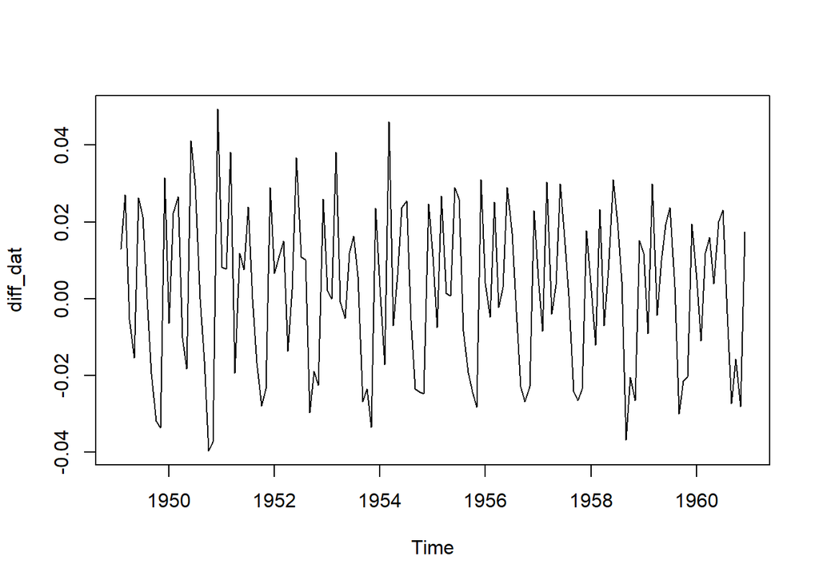

```r
plot(diff_dat)
```

We have eventually removed the trend and the non homogeneous variance.

### 2.4 Fit a linear regression

```r
# Fit a linear model with time as the predictor
time <- seq_along(AirPassengers)
model <- lm(airpassengers_transformed ~ time)
summary(model)
```

```
##
## Call:
## lm(formula = airpassengers_transformed ~ time)
##
## Residuals:
##      Min       1Q   Median       3Q      Max
## -0.07366 -0.01921 -0.00080  0.02039  0.05851
##
## Coefficients:
##              Estimate Std. Error t value Pr(>|t|)
## (Intercept) 2.581e+00  4.735e-03  545.02   <2e-16 ***
## time        1.987e-03  5.666e-05   35.08   <2e-16 ***
## ---
## Signif. codes:  0 '***' 0.001 '**' 0.01 '*' 0.05 '.' 0.1 ' ' 1
##
## Residual standard error: 0.02826 on 142 degrees of freedom
## Multiple R-squared:  0.8965, Adjusted R-squared:  0.8958
## F-statistic:  1230 on 1 and 142 DF,  p-value: < 2.2e-16
```

After fitting the simple linear regression time variable is statistically significant since the p-value is close to 0.

```r
# Perform the Breusch-Pagan test
bptest(model)
```

```
##
##  studentized Breusch-Pagan test
##
## data:  model
## BP = 0.087102, df = 1, p-value = 0.7679
```

We keep the null hypothesis of homoskedasticity since the p-value is very large (0.7679).

### 2.5 Forecasting with Prophet

First we need to create the needed dataframe.

```r
airpas.df = data.frame(
  ds=as.yearmon(time(AirPassengers)),
  y=AirPassengers)
```

Now, we create the model and we store it in **m**:

```r
m <- prophet::prophet(airpas.df)
```

We create 365 future values and we store them in **future**

```r
future = prophet::make_future_dataframe(m, periods=365)
```

We perform the prediction stored in **forecast** and we plot them.

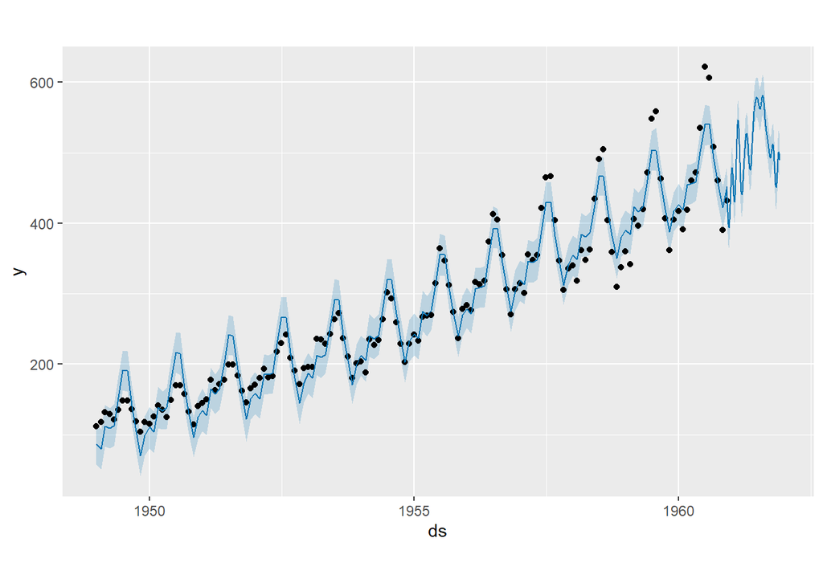

```r
forecast = predict(m, future)

plot(m,forecast)
```

```r
dyplot.prophet(m, forecast)
```

[interactive chart not shown]

In the following graph we decompose the trend and seasonality.

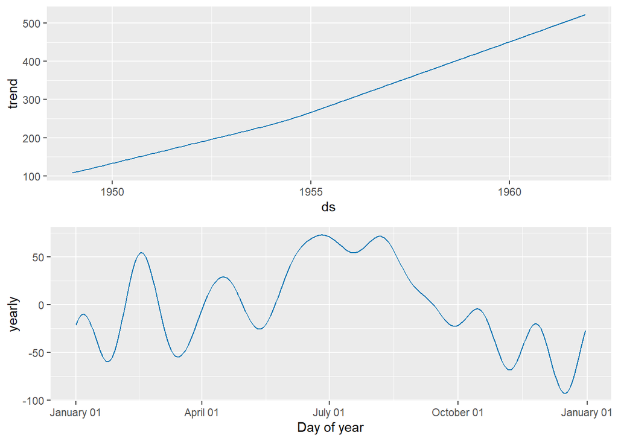

```r
prophet_plot_components(m, forecast)
```

## 3. Forecasting with ETS models

### 3.1 Analysis from Data Camp course (Forecasting in R)

From the book of (Hyndman and Athanasopoulos, 2023): You can go to section 4. Bibliography to check all references.

[video not shown]

https://otexts.com/fpp2/ets-forecasting.html

Particularly Exponential Smoothing State Space models (ETS models).

For example, for model

Therefore

$\hat{y}_{T+1|T} = l_T + b_T$

Similarly,

$\hat{y}_{T+2} = (l_{T+1} + b_{T+1})(1 + \varepsilon_{T+2}) = [(l_T + b_T)(1 + \alpha\varepsilon_{T+1}) + b_T + \beta(l_T + b_T)\varepsilon_{T+1}](1 + \varepsilon_{T+2})$

Therefore,

$\hat{y}_{T+2|T} = l_T + 2b_T$,

and so on.

These forecasts are identical to the forecasts from Holt’s linear method, and also to those from model ETS(A,A,N). Thus, the point forecasts obtained from the method and from the two models that underlie the method are identical (assuming that the same parameter values are used). ETS point forecasts constructed in this way are equal to the means of the forecast distributions, except for the models with multiplicative seasonality (Hyndman et al., 2008).

```r
aust <- window(austourists, start=2005)
fit <- ets(aust)
summary(fit)
```

```
## ETS(M,A,M)
##
## Call:
##  ets(y = aust)
##
##   Smoothing parameters:
##     alpha = 0.1908
##     beta  = 0.0392
##     gamma = 2e-04
##
##   Initial states:
##     l = 32.3679
##     b = 0.9281
##     s = 1.0218 0.9628 0.7683 1.2471
##
##   sigma:  0.0383
##
##      AIC     AICc      BIC
## 224.8628 230.1569 240.9205
##
## Training set error measures:
##                      ME     RMSE     MAE        MPE     MAPE     MASE      ACF1
## Training set 0.04836907 1.670893 1.24954 -0.1845609 2.692849 0.409454 0.2005962
```

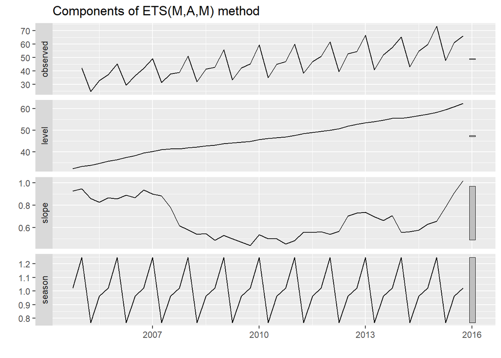

```r
autoplot(fit)
```

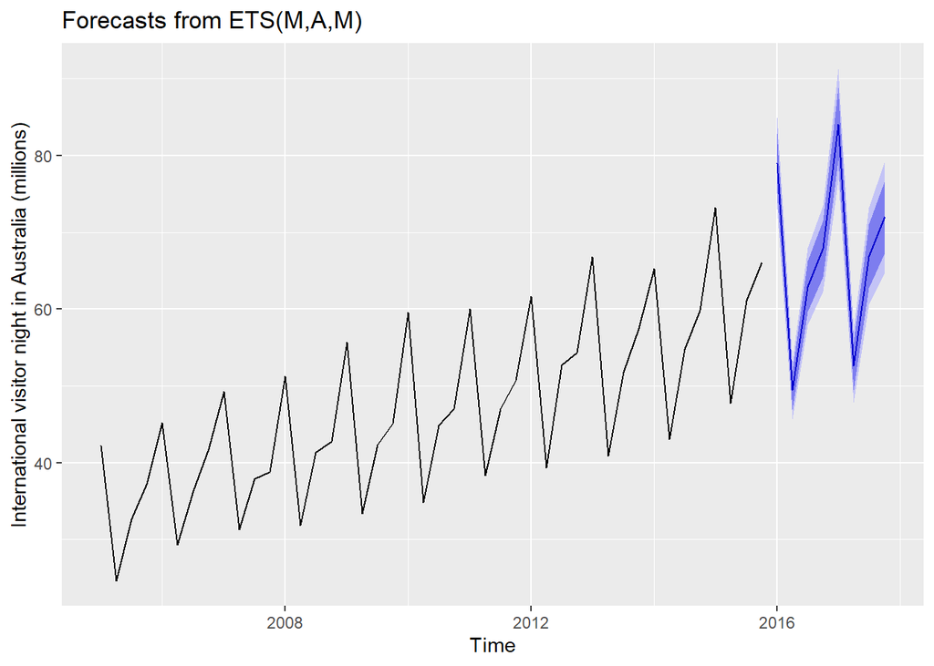

```r
fit %>% forecast(h=8) %>%
  autoplot() +
  ylab("International visitor night in Australia (millions)")
```

Prediction intervals within the context of statistical forecasting models. Here is the transcription:

For most ETS models, a prediction interval can be written as

$\hat{y}_{T+h|T} \pm c\sigma_h$,

Table 7.8: Forecast variance expressions for each additive state space model, where $\sigma^2$ is the residual variance, $m$ is the seasonal period, and $k$ is the integer part of $(h - 1)/m$ (i.e., the number of complete years in the forecast period prior to time $T + h$).

Model (A,N,N):
$$\sigma^2_h = \sigma^2 [1
+ \alpha^2(h - 1)]$$

Model (A,A,N):
$$\sigma^2_h = \sigma^2 [1
+ (h - 1)\{\alpha^2 + \alpha\beta h + \frac{1}{6}\beta^2h(2h - 1)\}]$$

Model (A,Ad,N):
$$\sigma^2_h = \sigma^2
[1 + \alpha^2(h - 1) + \frac{\beta\phi h}{(1-\phi)^2} \{2\alpha(1 -
\phi) + \beta\phi\} - \frac{\beta\phi(1-\phi^h)}{(1-\phi)^2(1-\phi^2)}
\{2\alpha(1 - \phi) + \beta\phi(1 + 2\phi - \phi^h)\}]$$

Model (A,N,A):
$$\sigma^2_h = \sigma^2 [1
+ \alpha^2(h - 1) + \gamma k(2\alpha + \gamma)]$$

Model (A,A,A):
$$\sigma^2_h = \sigma^2 [1
+ (h - 1)\{\alpha^2 + \alpha\beta h + \frac{1}{6}\beta^2h(2h - 1)\} +
\gamma k \{2\alpha + \gamma + \beta m(k + 1)\}]$$

Model (A,Ad,A):
$$\sigma^2_h = \sigma^2
[1 + \alpha^2(h - 1) + \gamma k(2\alpha + \gamma) + \frac{\beta\phi
h}{(1-\phi)^2} \{2\alpha(1 - \phi) + \beta\phi\} -
\frac{\beta\phi(1-\phi^h)}{(1-\phi)^2(1-\phi^2)} \{2\alpha(1 - \phi) +
\beta\phi(1 + 2\phi - \phi^h)\} + \frac{2\beta\gamma
h}{(1-\phi)(1-\phi^m)} \{k(1 - \phi) - \phi^m(1 - \phi^{mk})\}]$$

These expressions are used to calculate the forecast variance for different ETS models, which are categorized by whether they have an additive (A) or multiplicative (M) trend, and whether they include a damping factor (d) in the trend. The components $\alpha$, $\beta$, and $\gamma$ are smoothing parameters for the level, trend, and seasonal components, respectively. The $\phi$ represents the damping factor, and $\sigma^2$ is the residual variance of the model.

### 3.2 Analysis with Prophet

We create first the adequate dataframe:

```r
aust.df = data.frame(
  ds=as.yearmon(time(austourists)),
  y=austourists)
```

We compute then the model, future and forecast adjusting the frequency to quarter:

```r
m <- prophet::prophet(aust.df)
future = prophet::make_future_dataframe(m, periods=8,freq = "quarter")
forecast = predict(m, future)
```

We plot a static graph:

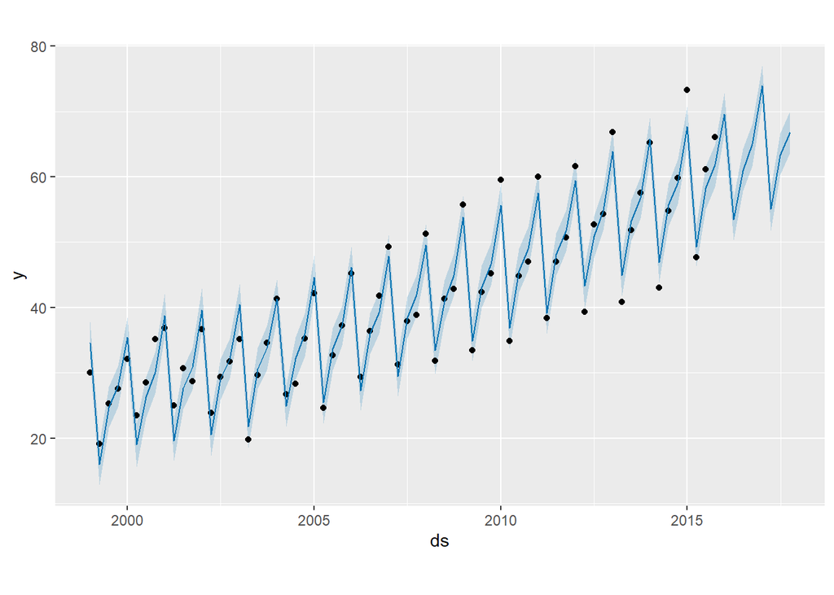

```r
plot(m,forecast)
```

Finally we plot a dynamic graph:

```r
dyplot.prophet(m, forecast)
```

[interactive chart not shown]

### 3.3 Comparing the models

```r
  (b<-sqrt(sum(fit$residuals^2)))
```

```
## [1] 0.22954
```

```r
  a<- as.vector(forecast[c('yhat')])
  (c<-sqrt(sum((aust.df$y- a$yhat[1:68])^2)))
```

```
## [1] 20.64579
```

```r
#sum(fit$residuals^2)
```

The value of the squared root of the sum of the residuals for the ets model is 0.22954 and for the Prophet model is 20.6457874.

Thus the performance with this metric is worst with the Prophet model.

## 4. Bibliography

Hand, D. J. (2009). Forecasting with Exponential Smoothing: The State Space Approach by Rob J. Hyndman, Anne B. Koehler, J. Keith Ord, Ralph D. Snyder. International Statistical Review, 77(2), 315–316. https://doi.org/10.1111/J.1751-5823.2009.00085_17.X

Hyndman, Rob J. (2023). Rob J Hyndman – Forecasting with Exponential Smoothing: the State Space Approach. https://robjhyndman.com/expsmooth/

Hyndman, Rob J. . (2024). Forecasting in R - DataCamp Learn. https://app.datacamp.com/learn/courses/forecasting-in-r

Hyndman, Rob J. and Athanasopoulos, George. (2023). 7.7 Forecasting with ETS models | Forecasting: Principles and Practice (2nd ed). https://otexts.com/fpp2/ets-forecasting.html

Peterson, Amy. (2024). Reporting with R Markdown - DataCamp Learn. https://app.datacamp.com/learn/courses/reporting-with-rmarkdown

Wickham, H. (2016). Ggplot2 : elegant graphics for data analysis.

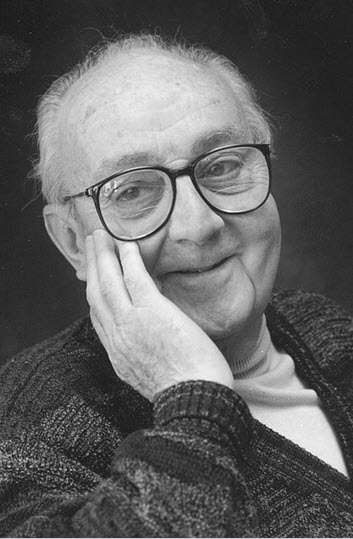

#### *“All models are wrong, but some are useful.”*

― [George Box](https://en.wikipedia.org/wiki/All_models_are_wrong)